# Census Income Prediction Project

Rajasekhar Madabattula

2024-01-25

# 1 Import data, factorize, explore

## 1.1 Import Libraries

This section initiates the use of crucial R libraries such as C50, e1071, caret, psych, rpart, tidyverse, rpart.plot, kernlab, rminer, matrixStats, and knitr. These libraries play integral roles in tasks spanning data manipulation, modeling, and visualization.

```r
options(rgl.useNULL = TRUE)
library(C50)
library(e1071)
library(caret)
library(psych)
library(rpart)
library(tidyverse)
```

```r
library(rpart.plot)
#library(rJava)
#library(RWeka)
library(kernlab)
library(rminer)
library(matrixStats)
library(knitr)
library(tidyverse)
```

Task I - EDA (25%) Perform exploratory data analysis on the dataset. Add text to note items from code blocks you have observed. Is this target variable categorical or numeric? List all of the supervised models covered in class and note which are appropriate to use for the task in this project and which are not. Do not build any models that are inappropriate for the task. As a reference, if you only do summary(), str() and pairs.panels() that would be insufficient EDA. Use multiple graphs and tables to explore all columns. Explore target and predictors together. What is the distribution of the target variable? # Importing the CSV Code is dedicated to loading the census dataset and conducting preliminary explorations using functions like str() and summary(). The primary goal is to comprehend the dataset’s structure, variable characteristics, and fundamental statistics.Leveraging the na.omit() function, this segment ensures the removal of rows containing missing values from the dataset, ensuring a pristine dataset for subsequent modeling.

```r
mydir <- getwd()
setwd(mydir)

df <- read.csv(file = "census data.csv", stringsAsFactors = TRUE)
str(df)
```

```
## 'data.frame':    32561 obs. of  15 variables:
##  $ age           : int  39 50 38 53 28 37 49 52 31 42 ...
##  $ workclass     : Factor w/ 9 levels "Federal-gov",..: 8 7 5 5 5 5 5 7 5 5 ...
##  $ fnlwgt        : int  77516 83311 215646 234721 338409 284582 160187 209642 45781 159449 ...
##  $ education     : Factor w/ 16 levels "10th","11th",..: 10 10 12 2 10 13 7 12 13 10 ...
##  $ education.num : int  13 13 9 7 13 14 5 9 14 13 ...
##  $ marital.status: Factor w/ 7 levels "Divorced","Married-AF-spouse",..: 5 3 1 3 3 3 4 3 5 3 ...
##  $ occupation    : Factor w/ 14 levels "Adm-clerical",..: 1 4 6 6 10 4 8 4 10 4 ...
##  $ relationship  : Factor w/ 6 levels "Husband","Not-in-family",..: 2 1 2 1 6 6 2 1 2 1 ...
##  $ race          : Factor w/ 5 levels "Amer-Indian-Eskimo",..: 5 5 5 3 3 5 3 5 5 5 ...
##  $ sex           : Factor w/ 2 levels "Female","Male": 2 2 2 2 1 1 1 2 1 2 ...
##  $ capital.gain  : int  2174 0 0 0 0 0 0 0 14084 5178 ...
##  $ capital.loss  : int  0 0 0 0 0 0 0 0 0 0 ...
##  $ hours.per.week: int  40 13 40 40 40 40 16 45 50 40 ...
##  $ native.country: Factor w/ 42 levels "Cambodia","Canada",..: 40 40 40 40 5 40 23 40 40 40 ...
##  $ y             : Factor w/ 2 levels "<=50K",">50K": 1 1 1 1 1 1 1 2 2 2 ...
```

```r
summary(df)
```

```
##       age                   workclass         fnlwgt
##  Min.   :17.00   Private         :22696   Min.   :  12285
##  1st Qu.:28.00   Self-emp-not-inc: 2541   1st Qu.: 117827
##  Median :37.00   Local-gov       : 2093   Median : 178356
##  Mean   :38.58   Other           : 1836   Mean   : 189778
##  3rd Qu.:48.00   State-gov       : 1298   3rd Qu.: 237051
##  Max.   :90.00   Self-emp-inc    : 1116   Max.   :1484705
##                  (Other)         :  981
##         education     education.num                 marital.status
##  HS-grad     :10501   Min.   : 1.00   Divorced             : 4443
##  Some-college: 7291   1st Qu.: 9.00   Married-AF-spouse    :   23
##  Bachelors   : 5355   Median :10.00   Married-civ-spouse   :14976
##  Masters     : 1723   Mean   :10.08   Married-spouse-absent:  418
##  Assoc-voc   : 1382   3rd Qu.:12.00   Never-married        :10683
##  11th        : 1175   Max.   :16.00   Separated            : 1025
##  (Other)     : 5134                   Widowed              :  993
##            occupation           relationship                   race
##  Other-service  :5138   Husband       :13193   Amer-Indian-Eskimo:  311
##  Prof-specialty :4140   Not-in-family : 8305   Asian-Pac-Islander: 1039
##  Craft-repair   :4099   Other-relative:  981   Black             : 3124
##  Exec-managerial:4066   Own-child     : 5068   Other             :  271
##  Adm-clerical   :3770   Unmarried     : 3446   White             :27816
##  Sales          :3650   Wife          : 1568
##  (Other)        :7698
##      sex         capital.gain    capital.loss    hours.per.week
##  Female:10771   Min.   :    0   Min.   :   0.0   Min.   : 1.00
##  Male  :21790   1st Qu.:    0   1st Qu.:   0.0   1st Qu.:40.00
##                 Median :    0   Median :   0.0   Median :40.00
##                 Mean   : 1078   Mean   :  87.3   Mean   :40.44
##                 3rd Qu.:    0   3rd Qu.:   0.0   3rd Qu.:45.00
##                 Max.   :99999   Max.   :4356.0   Max.   :99.00
##
##        native.country      y
##  United-States:29170   <=50K:24720
##  Mexico       :  643   >50K : 7841
##  Other        :  583
##  Philippines  :  198
##  Germany      :  137
##  Canada       :  121
##  (Other)      : 1709
```

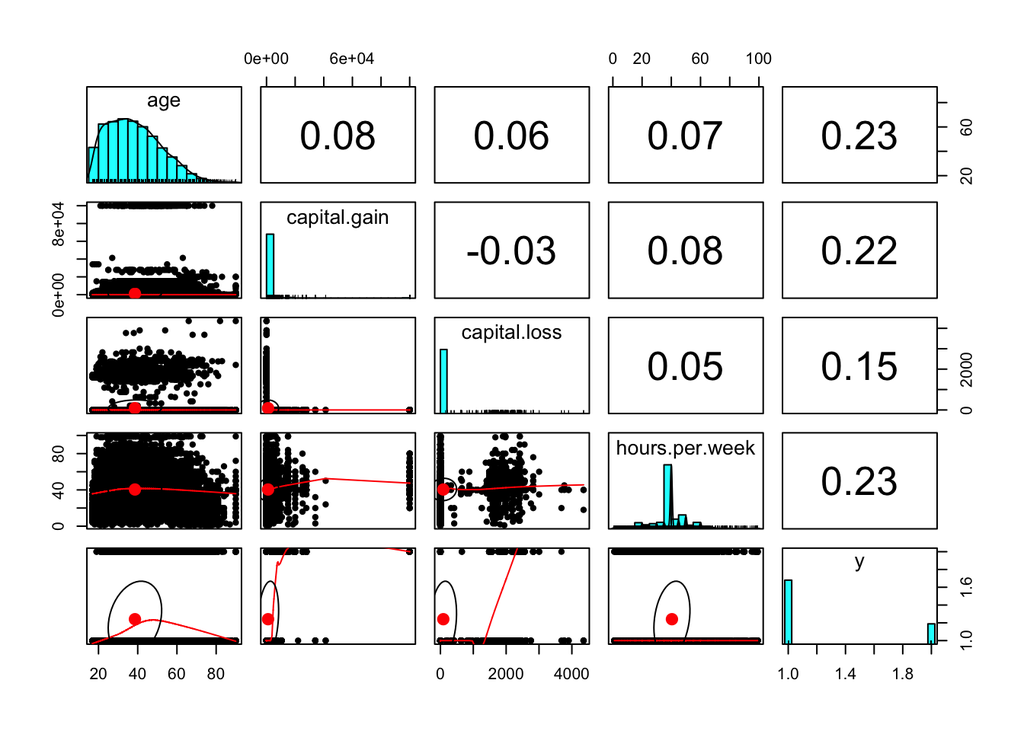

```r
df %>% select(age,capital.gain, capital.loss, hours.per.week,y) %>% pairs.panels()
```

```r
#Data Cleaning
df <- df %>% na.omit()
str(df)
```

```
## 'data.frame':    32561 obs. of  15 variables:
##  $ age           : int  39 50 38 53 28 37 49 52 31 42 ...
##  $ workclass     : Factor w/ 9 levels "Federal-gov",..: 8 7 5 5 5 5 5 7 5 5 ...
##  $ fnlwgt        : int  77516 83311 215646 234721 338409 284582 160187 209642 45781 159449 ...
##  $ education     : Factor w/ 16 levels "10th","11th",..: 10 10 12 2 10 13 7 12 13 10 ...
##  $ education.num : int  13 13 9 7 13 14 5 9 14 13 ...
##  $ marital.status: Factor w/ 7 levels "Divorced","Married-AF-spouse",..: 5 3 1 3 3 3 4 3 5 3 ...
##  $ occupation    : Factor w/ 14 levels "Adm-clerical",..: 1 4 6 6 10 4 8 4 10 4 ...
##  $ relationship  : Factor w/ 6 levels "Husband","Not-in-family",..: 2 1 2 1 6 6 2 1 2 1 ...
##  $ race          : Factor w/ 5 levels "Amer-Indian-Eskimo",..: 5 5 5 3 3 5 3 5 5 5 ...
##  $ sex           : Factor w/ 2 levels "Female","Male": 2 2 2 2 1 1 1 2 1 2 ...
##  $ capital.gain  : int  2174 0 0 0 0 0 0 0 14084 5178 ...
##  $ capital.loss  : int  0 0 0 0 0 0 0 0 0 0 ...
##  $ hours.per.week: int  40 13 40 40 40 40 16 45 50 40 ...
##  $ native.country: Factor w/ 42 levels "Cambodia","Canada",..: 40 40 40 40 5 40 23 40 40 40 ...
##  $ y             : Factor w/ 2 levels "<=50K",">50K": 1 1 1 1 1 1 1 2 2 2 ...
```

```r
summary(df)
```

```
##       age                   workclass         fnlwgt
##  Min.   :17.00   Private         :22696   Min.   :  12285
##  1st Qu.:28.00   Self-emp-not-inc: 2541   1st Qu.: 117827
##  Median :37.00   Local-gov       : 2093   Median : 178356
##  Mean   :38.58   Other           : 1836   Mean   : 189778
##  3rd Qu.:48.00   State-gov       : 1298   3rd Qu.: 237051
##  Max.   :90.00   Self-emp-inc    : 1116   Max.   :1484705
##                  (Other)         :  981
##         education     education.num                 marital.status
##  HS-grad     :10501   Min.   : 1.00   Divorced             : 4443
##  Some-college: 7291   1st Qu.: 9.00   Married-AF-spouse    :   23
##  Bachelors   : 5355   Median :10.00   Married-civ-spouse   :14976
##  Masters     : 1723   Mean   :10.08   Married-spouse-absent:  418
##  Assoc-voc   : 1382   3rd Qu.:12.00   Never-married        :10683
##  11th        : 1175   Max.   :16.00   Separated            : 1025
##  (Other)     : 5134                   Widowed              :  993
##            occupation           relationship                   race
##  Other-service  :5138   Husband       :13193   Amer-Indian-Eskimo:  311
##  Prof-specialty :4140   Not-in-family : 8305   Asian-Pac-Islander: 1039
##  Craft-repair   :4099   Other-relative:  981   Black             : 3124
##  Exec-managerial:4066   Own-child     : 5068   Other             :  271
##  Adm-clerical   :3770   Unmarried     : 3446   White             :27816
##  Sales          :3650   Wife          : 1568
##  (Other)        :7698
##      sex         capital.gain    capital.loss    hours.per.week
##  Female:10771   Min.   :    0   Min.   :   0.0   Min.   : 1.00
##  Male  :21790   1st Qu.:    0   1st Qu.:   0.0   1st Qu.:40.00
##                 Median :    0   Median :   0.0   Median :40.00
##                 Mean   : 1078   Mean   :  87.3   Mean   :40.44
##                 3rd Qu.:    0   3rd Qu.:   0.0   3rd Qu.:45.00
##                 Max.   :99999   Max.   :4356.0   Max.   :99.00
##
##        native.country      y
##  United-States:29170   <=50K:24720
##  Mexico       :  643   >50K : 7841
##  Other        :  583
##  Philippines  :  198
##  Germany      :  137
##  Canada       :  121
##  (Other)      : 1709
```

# 2 Explroing the data by comparing predictors with target variable

Employing ggplot, the code engages in visualizing and analyzing the data through histograms, boxplots, and other graphical representations. The emphasis lies on gaining insights into variable distributions and relationships. This bar graph is showing what is the majority class in the tareget variable where >50K is 7500 count and <=50k is approximately 25000. I want to check the age distribution so we can check which age people are we predicting for, in the given data 20 to 40 age people are the major.

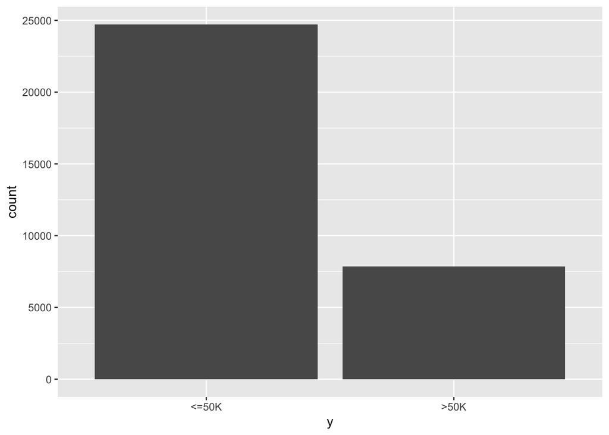

```r
# Visualize the distribution of the target variable

ggplot(df, aes(x=y)) + geom_bar()
```

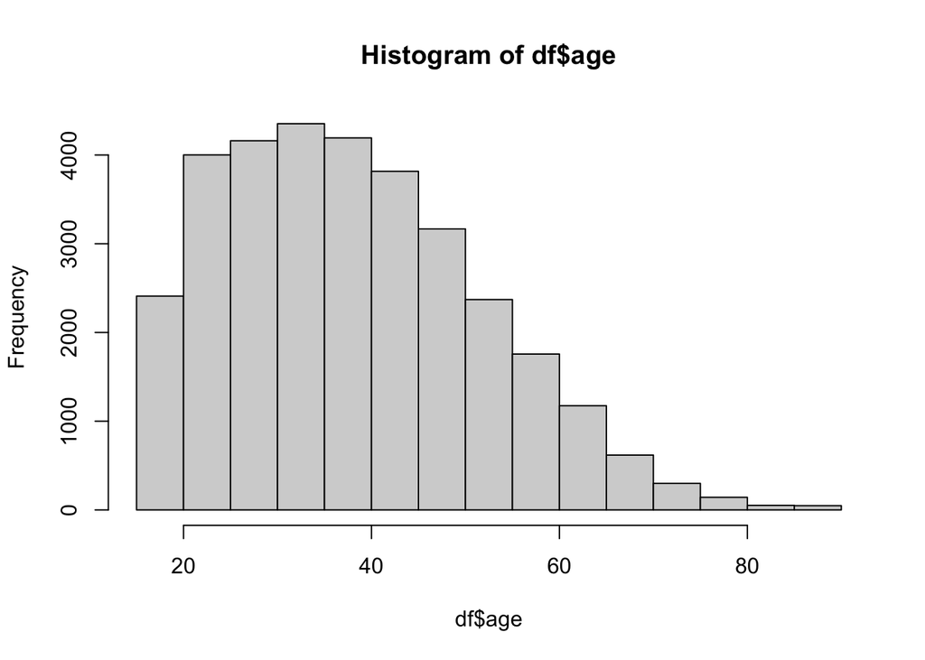

```r
# Explore numerical features

hist(df$age)
```

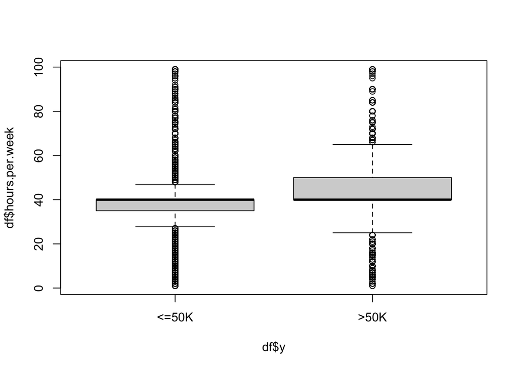

```r
boxplot(df$hours.per.week ~ df$y)
```

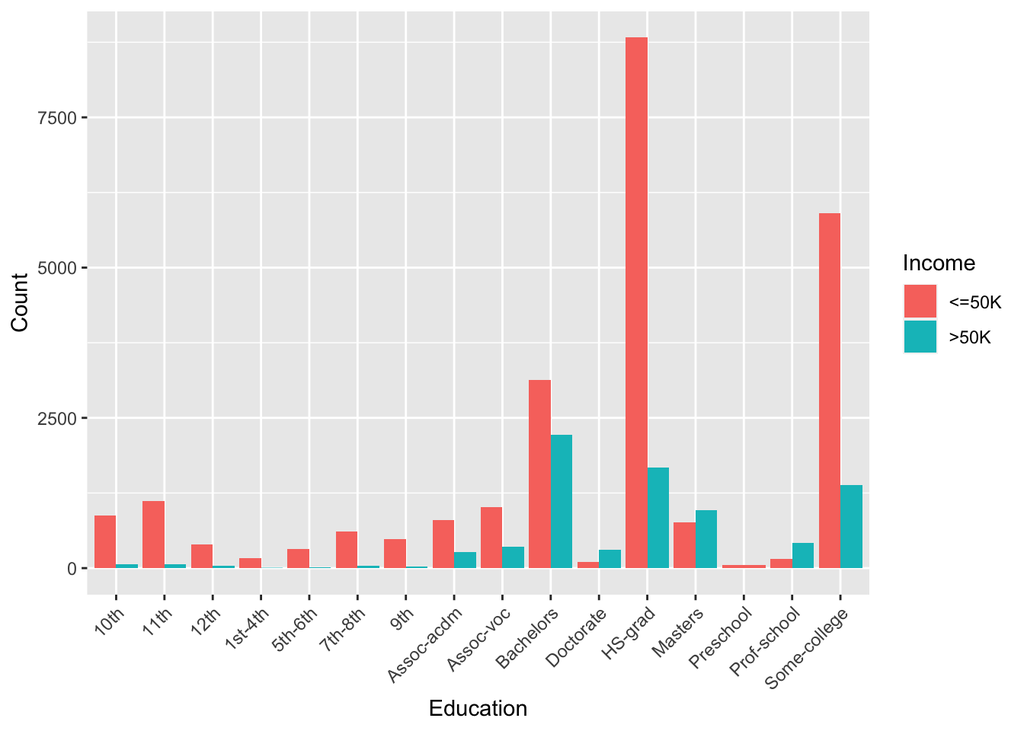

```r
# Explore relationships between features and target
ggplot(df, aes(x = education, fill = y)) +
  geom_bar(position = "dodge", stat = "count") +
  theme(axis.text.x = element_text(angle = 45, hjust = 1)) +
  labs(x = "Education", y = "Count", fill = "Income")
```

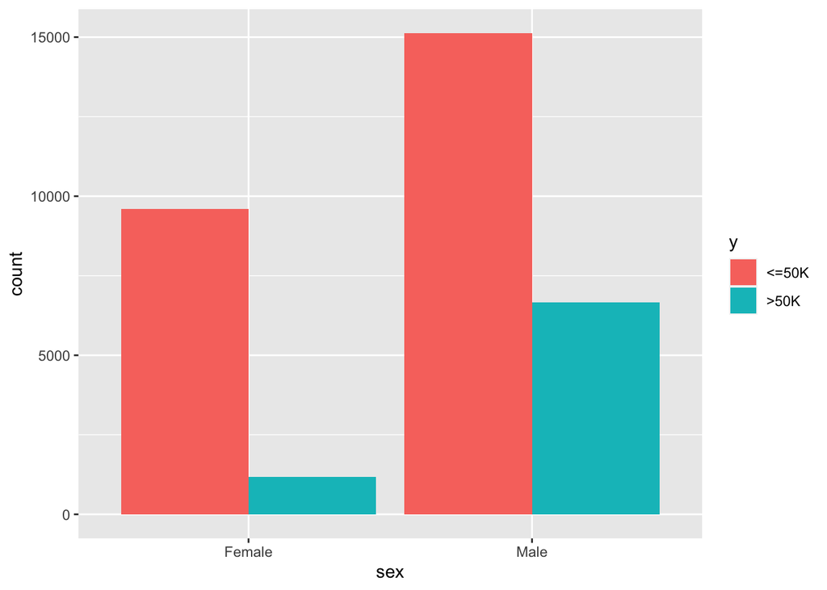

```r
ggplot(df, aes(x=sex, fill = y))+geom_bar(position = 'dodge')
```

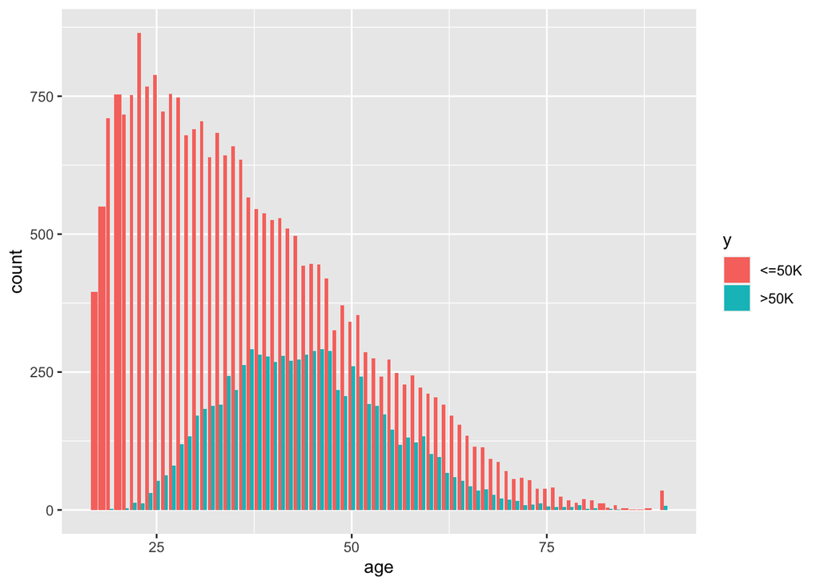

```r
ggplot(df, aes(x=age, fill = y))+geom_bar(position = 'dodge')
```

```r
df %>% select(y,marital.status) %>% table()
```

```
##        marital.status
## y       Divorced Married-AF-spouse Married-civ-spouse Married-spouse-absent
##   <=50K     3980                13               8284                   384
##   >50K       463                10               6692                    34
##        marital.status
## y       Never-married Separated Widowed
##   <=50K         10192       959     908
##   >50K            491        66      85
```

```r
df %>% select(y,occupation) %>% table()
```

```
##        occupation
## y       Adm-clerical Armed-Forces Craft-repair Exec-managerial Farming-fishing
##   <=50K         3263            8         3170            2098             879
##   >50K           507            1          929            1968             115
##        occupation
## y       Handlers-cleaners Machine-op-inspct Other-service Priv-house-serv
##   <=50K              1284              1752          4810             148
##   >50K                 86               250           328               1
##        occupation
## y       Prof-specialty Protective-serv Sales Tech-support Transport-moving
##   <=50K           2281             438  2667          645             1277
##   >50K            1859             211   983          283              320
```

```r
df %>% select(y,relationship) %>% table()
```

```
##        relationship
## y       Husband Not-in-family Other-relative Own-child Unmarried Wife
##   <=50K    7275          7449            944      5001      3228  823
##   >50K     5918           856             37        67       218  745
```

```r
df %>% select(y,race) %>% table()
```

```
##        race
## y       Amer-Indian-Eskimo Asian-Pac-Islander Black Other White
##   <=50K                275                763  2737   246 20699
##   >50K                  36                276   387    25  7117
```

Task II Data Preparation (15%): Prepare your data for modeling. What tasks should be performed to ensure your model metrics can be used to identify over/underfitting?

This involves the preparation of data for modeling, encompassing the creation of training and test datasets via the createDataPartition function. This step is pivotal for effective model validation and mitigating issues like overfitting or underfitting.

```r
set.seed(100)

# you enter the proportion for the split here. I'd suggest .8
inTrain <- createDataPartition(df$y, p=.7, list=FALSE)

# use the row indexes from line 87 to create the 2 sets.
# train includes the index, test excludes the index.
train_set <- df[inTrain,]
test_set <- df[-inTrain,]
train_target <- df[inTrain,15]
test_target <- df[-inTrain,15]
train_input <- df[inTrain,-15]
test_input <- df[-inTrain,-15]

#summary of train_set
train_input %>% summary()
```

```
##       age                  workclass         fnlwgt               education
##  Min.   :17.0   Private         :15939   Min.   :  12285   HS-grad     :7319
##  1st Qu.:28.0   Self-emp-not-inc: 1789   1st Qu.: 118721   Some-college:5101
##  Median :37.0   Local-gov       : 1442   Median : 179008   Bachelors   :3766
##  Mean   :38.5   Other           : 1257   Mean   : 190561   Masters     :1191
##  3rd Qu.:47.0   State-gov       :  923   3rd Qu.: 238008   Assoc-voc   : 975
##  Max.   :90.0   Self-emp-inc    :  770   Max.   :1484705   11th        : 844
##                 (Other)         :  673                     (Other)     :3597
##  education.num                 marital.status            occupation
##  Min.   : 1.00   Divorced             : 3117   Other-service  :3515
##  1st Qu.: 9.00   Married-AF-spouse    :   18   Prof-specialty :2889
##  Median :10.00   Married-civ-spouse   :10416   Craft-repair   :2850
##  Mean   :10.09   Married-spouse-absent:  299   Exec-managerial:2811
##  3rd Qu.:12.00   Never-married        : 7533   Adm-clerical   :2674
##  Max.   :16.00   Separated            :  720   Sales          :2628
##                  Widowed              :  690   (Other)        :5426
##          relationship                  race           sex
##  Husband       :9163   Amer-Indian-Eskimo:  222   Female: 7510
##  Not-in-family :5912   Asian-Pac-Islander:  716   Male  :15283
##  Other-relative: 671   Black             : 2173
##  Own-child     :3555   Other             :  183
##  Unmarried     :2380   White             :19499
##  Wife          :1112
##
##   capital.gain    capital.loss     hours.per.week        native.country
##  Min.   :    0   Min.   :   0.00   Min.   : 1.00   United-States:20399
##  1st Qu.:    0   1st Qu.:   0.00   1st Qu.:40.00   Mexico       :  456
##  Median :    0   Median :   0.00   Median :40.00   Other        :  407
##  Mean   : 1104   Mean   :  85.84   Mean   :40.45   Philippines  :  128
##  3rd Qu.:    0   3rd Qu.:   0.00   3rd Qu.:45.00   Germany      :   95
##  Max.   :99999   Max.   :4356.00   Max.   :99.00   Canada       :   87
##                                                    (Other)      : 1221
```

```r
#summary of test_set
test_input %>% summary()
```

```
##       age                   workclass        fnlwgt               education
##  Min.   :17.00   Private         :6757   Min.   :  19302   HS-grad     :3182
##  1st Qu.:28.00   Self-emp-not-inc: 752   1st Qu.: 115930   Some-college:2190
##  Median :37.00   Local-gov       : 651   Median : 177140   Bachelors   :1589
##  Mean   :38.78   Other           : 579   Mean   : 187952   Masters     : 532
##  3rd Qu.:48.00   State-gov       : 375   3rd Qu.: 235298   Assoc-voc   : 407
##  Max.   :90.00   Self-emp-inc    : 346   Max.   :1455435   Assoc-acdm  : 334
##                  (Other)         : 308                     (Other)     :1534
##  education.num                 marital.status           occupation
##  Min.   : 1.00   Divorced             :1326   Other-service  :1623
##  1st Qu.: 9.00   Married-AF-spouse    :   5   Exec-managerial:1255
##  Median :10.00   Married-civ-spouse   :4560   Prof-specialty :1251
##  Mean   :10.07   Married-spouse-absent: 119   Craft-repair   :1249
##  3rd Qu.:12.00   Never-married        :3150   Adm-clerical   :1096
##  Max.   :16.00   Separated            : 305   Sales          :1022
##                  Widowed              : 303   (Other)        :2272
##          relationship                  race          sex        capital.gain
##  Husband       :4030   Amer-Indian-Eskimo:  89   Female:3261   Min.   :    0
##  Not-in-family :2393   Asian-Pac-Islander: 323   Male  :6507   1st Qu.:    0
##  Other-relative: 310   Black             : 951                 Median :    0
##  Own-child     :1513   Other             :  88                 Mean   : 1017
##  Unmarried     :1066   White             :8317                 3rd Qu.:    0
##  Wife          : 456                                           Max.   :99999
##
##   capital.loss     hours.per.week       native.country
##  Min.   :   0.00   Min.   : 1.0   United-States:8771
##  1st Qu.:   0.00   1st Qu.:40.0   Mexico       : 187
##  Median :   0.00   Median :40.0   Other        : 176
##  Mean   :  90.71   Mean   :40.4   Philippines  :  70
##  3rd Qu.:   0.00   3rd Qu.:45.0   Germany      :  42
##  Max.   :4356.00   Max.   :99.0   Puerto-Rico  :  40
##                                   (Other)      : 482
```

Task III - Model Building (30%) Build a variety of models and keep them to show your efforts to achieve good performance. Your stakeholders prefer interpretability over performance. Consider this as you choose your models. How many models are sufficient? Enough to show that you found underfitting, overfitting and a good balance between the two. Your stakeholders still want a good model however.

Various models, including C5.0, Naive Bayes, and Rpart, are constructed. Each model is trained on the designated training set, and predictions are extended to both training and test sets. Model performance is subsequently evaluated using metrics such as accuracy, precision, and F1 score.

All Known Modelling Algorithms

1. Decision tree
2. C5.0
3. Naive Bayes
4. Linear Regression ( Not for classification)
5. RPart
6. M5P in RWeka ( Not for classification)
7. MLP
8. KSVM
9. Ibk
10. Clustering K Means

Suitable for categorical: C5.0 Rpart Naive Bayes

Which metrics are appropriate for the prediction task?

# 3 C5.0 Model

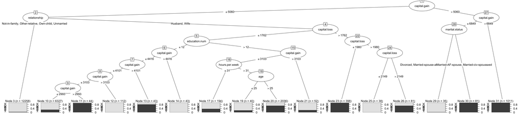

```r
tree_cf_1 <- C5.0(y~.,train_set,control = C5.0Control(CF=.0))
plot(tree_cf_1)
```

```r
#Summary of the C5.0 Model
summary(tree_cf_1)
```

```
##
## Call:
## C5.0.formula(formula = y ~ ., data = train_set, control = C5.0Control(CF = 0))
##
##
## C5.0 [Release 2.07 GPL Edition]      Tue Dec  5 23:57:25 2023
## -------------------------------
##
## Class specified by attribute `outcome'
##
## Read 22793 cases (15 attributes) from undefined.data
##
## Decision tree:
##
## capital.gain > 5060:
## :...capital.gain > 6849: >50K (1011/11)
## :   capital.gain <= 6849:
## :   :...marital.status in {Divorced,Married-spouse-absent,Never-married,
## :       :                  Separated,Widowed}: <=50K (35/1)
## :       marital.status in {Married-AF-spouse,
## :                          Married-civ-spouse}: >50K (81/1)
## capital.gain <= 5060:
## :...relationship in {Not-in-family,Other-relative,Own-child,
##     :                Unmarried}: <=50K (12258/600)
##     relationship in {Husband,Wife}:
##     :...capital.loss > 1762:
##         :...capital.loss <= 1980: >50K (398/9)
##         :   capital.loss > 1980:
##         :   :...capital.loss <= 2149: <=50K (38)
##         :       capital.loss > 2149: >50K (81/25)
##         capital.loss <= 1762:
##         :...education.num > 12:
##             :...capital.gain > 3103: <=50K (52/12)
##             :   capital.gain <= 3103:
##             :   :...hours.per.week <= 31: <=50K (194/70)
##             :       hours.per.week > 31:
##             :       :...age <= 25: <=50K (40/8)
##             :           age > 25: >50K (2036/629)
##             education.num <= 12:
##             :...capital.gain > 4416: <=50K (43)
```

[output cut: 21 more lines]

```
##    2480  3009    (b): class >50K
##
##
##  Attribute usage:
##
##  100.00% capital.gain
##   95.06% relationship
##   41.28% capital.loss
##   39.01% education.num
##    9.96% hours.per.week
##    9.11% age
##    0.51% marital.status
##
##
## Time: 0.1 secs
```

```r
#Predictions
tree_cf_1_train_predictions <- predict(tree_cf_1,train_set)
tree_cf_1_test_predictions <- predict(tree_cf_1,test_set)
# Training set confusion matrix 1
mmetric(train_set$y, tree_cf_1_train_predictions, metric="CONF")$conf
```

```
##        pred
## target  <=50K  >50K
##   <=50K 16619   685
##   >50K   2480  3009
```

```r
# Testing set confusion matrix 1
mmetric(test_set$y, tree_cf_1_test_predictions, metric="CONF")$conf
```

```
##        pred
## target  <=50K >50K
##   <=50K  7077  339
##   >50K   1105 1247
```

```r
# creating a vector with evaluation metrics.
evaluation_metrics_vector <- c("ACC","F1","PRECISION","TPR")
# Training set 1 evaluation metrics
mmetric(train_set$y, tree_cf_1_train_predictions, metric=evaluation_metrics_vector)
```

```
##        ACC        F11        F12 PRECISION1 PRECISION2       TPR1       TPR2
##   86.11416   91.30566   65.53414   87.01503   81.45642   96.04138   54.81873
```

```r
# Testing set 1 evaluation metrics
mmetric(test_set$y, tree_cf_1_test_predictions, metric=evaluation_metrics_vector)
```

```
##        ACC        F11        F12 PRECISION1 PRECISION2       TPR1       TPR2
##   85.21704   90.74240   63.33164   86.49474   78.62547   95.42880   53.01871
```

# 4 Naïve Bayes Model

```r
df_m1_nb <- naiveBayes(y~., train_set)
# Information of the trained Naïve Bayes Model
summary(df_m1_nb)
```

```
##           Length Class  Mode
## apriori    2     table  numeric
## tables    14     -none- list
## levels     2     -none- character
## isnumeric 14     -none- logical
## call       4     -none- call
```

```r
#Prediction
predicted_y_train1 <- predict(df_m1_nb, train_set)
#Confusion matrix of NB Training
mmetric(train_set$y, predicted_y_train1, metric="CONF")$conf
```

```
##        pred
## target  <=50K  >50K
##   <=50K 16164  1140
##   >50K   2765  2724
```

```r
#Evaluation Metrics of NB Training
mmetric(train_set$y, predicted_y_train1, metric=c("ACC","TPR","PRECISION","F1"))
```

```
##        ACC       TPR1       TPR2 PRECISION1 PRECISION2        F11        F12
##   82.86755   93.41193   49.62653   85.39278   70.49689   89.22253   58.24869
```

```r
#Prediction
predicted_y_test1 <- predict(df_m1_nb, test_set)
#Confusion matrix of NB Testing
mmetric(test_set$y, predicted_y_test1, metric="CONF")$conf
```

```
##        pred
## target  <=50K >50K
##   <=50K  6890  526
##   >50K   1184 1168
```

```r
#Evaluation Metrics of NB Testing
mmetric(test_set$y, predicted_y_test1, metric=c("ACC","TPR","PRECISION","F1"))
```

```
##        ACC       TPR1       TPR2 PRECISION1 PRECISION2        F11        F12
##   82.49386   92.90723   49.65986   85.33565   68.94923   88.96062   57.73604
```

# 5 Rpart Model

```r
metrics_list <- c("ACC","F1","PRECISION","TPR")
# regression tree using rpart
rpart_train_model <- rpart(train_target ~ ., data = train_input)
summary(rpart_train_model)
```

```
## Call:
## rpart(formula = train_target ~ ., data = train_input)
##   n= 22793
##
##           CP nsplit rel error    xerror        xstd
## 1 0.13016943      0 1.0000000 1.0000000 0.011760503
## 2 0.06649663      2 0.7396611 0.7396611 0.010523803
## 3 0.03752960      3 0.6731645 0.6731645 0.010136947
## 4 0.01000000      4 0.6356349 0.6356349 0.009903305
##
## Variable importance
##   relationship marital.status   capital.gain      education  education.num
##             24             24             10              9              9
##            sex     occupation            age hours.per.week
##              7              7              5              3
##
## Node number 1: 22793 observations,    complexity param=0.1301694
##   predicted class=<=50K  expected loss=0.2408195  P(node) =1
##     class counts: 17304  5489
##    probabilities: 0.759 0.241
##   left son=2 (12518 obs) right son=3 (10275 obs)
##   Primary splits:
##       relationship   splits as  RLLLLR, improve=1711.6060, (0 missing)
##       marital.status splits as  LRRLLLL, improve=1686.6210, (0 missing)
##       capital.gain   < 5119   to the left,  improve=1223.6750, (0 missing)
##       education      splits as  LLLLLLLLLRRLRLRL, improve= 885.8932, (0 missing)
##       education.num  < 12.5   to the left,  improve= 885.8932, (0 missing)
##   Surrogate splits:
##       marital.status splits as  LRRLLLL, agree=0.993, adj=0.985, (0 split)
##       sex            splits as  LR, agree=0.683, adj=0.296, (0 split)
##       age            < 33.5   to the left,  agree=0.650, adj=0.224, (0 split)
##       occupation     splits as  LLRRRLLLLRRLLR, agree=0.622, adj=0.161, (0 split)
##       hours.per.week < 43.5   to the left,  agree=0.607, adj=0.128, (0 split)
##
## Node number 2: 12518 observations,    complexity param=0.0375296
##   predicted class=<=50K  expected loss=0.06526602  P(node) =0.5492037
##     class counts: 11701   817
##    probabilities: 0.935 0.065
##   left son=4 (12294 obs) right son=5 (224 obs)
##   Primary splits:
```

[output cut: 45 more lines]

```
##
## Node number 7: 3097 observations
##   predicted class=>50K   expected loss=0.2692929  P(node) =0.135875
##     class counts:   834  2263
##    probabilities: 0.269 0.731
##
## Node number 12: 6809 observations
##   predicted class=<=50K  expected loss=0.2998972  P(node) =0.2987321
##     class counts:  4767  2042
##    probabilities: 0.700 0.300
##
## Node number 13: 369 observations
##   predicted class=>50K   expected loss=0.005420054  P(node) =0.01618918
##     class counts:     2   367
##    probabilities: 0.005 0.995
```

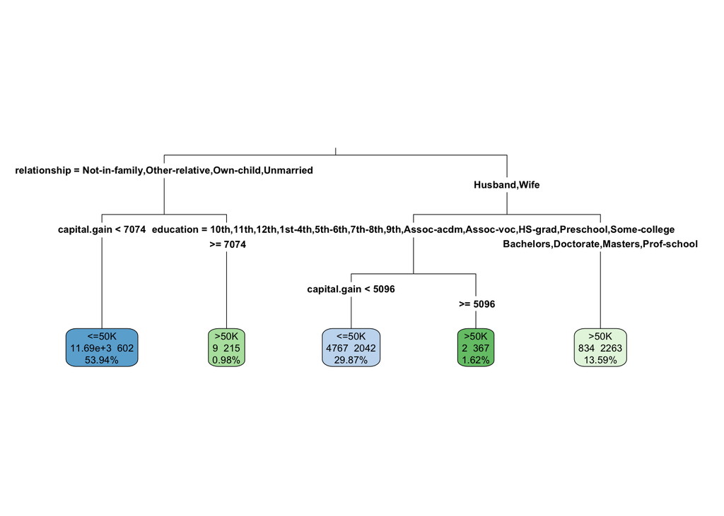

```r
# use the rpart.plot package to create a visualization
#The fallen.leaves parameter forces the leaf nodes to be aligned at the bottom of the plot, while the type and extra parameters affect the way the decisions and nodes are labeled
rpart.plot(rpart_train_model, digits = 4, fallen.leaves = TRUE, type = 3, extra = 101)
```

```r
# generate predictions for the testing and training dataset
predictions_rpart_test <- predict(rpart_train_model, test_input)
predictions_rpart_train <- predict(rpart_train_model, train_input)

#Confusion matrix of Rpart
mmetric(train_set$y, predictions_rpart_train, metric="CONF")$conf
```

```
##        pred
## target  <=50K  >50K
##   <=50K 16459   845
##   >50K   2644  2845
```

```r
#Confusion matrix of Rpart
mmetric(test_set$y, predictions_rpart_test, metric="CONF")$conf
```

```
##        pred
## target  <=50K >50K
##   <=50K  7014  402
##   >50K   1172 1180
```

```r
# Performance of predictions on train data
mmetric(train_target,predictions_rpart_train,metrics_list)
```

```
##        ACC        F11        F12 PRECISION1 PRECISION2       TPR1       TPR2
##   84.69267   90.41668   61.98932   86.15924   77.10027   95.11674   51.83093
```

```r
# Performance of predictions on test data
mmetric(test_target,predictions_rpart_test,metrics_list)
```

```
##        ACC        F11        F12 PRECISION1 PRECISION2       TPR1       TPR2
##   83.88616   89.91155   59.98983   85.68287   74.58913   94.57929   50.17007
```

The introduction of the Kernel Support Vector Machine (KSVM) model in your project signifies a strategic shift towards prioritizing predictive accuracy over model interpretability, aiming to enhance economic benefits for the company. This model, built using a Laplace kernel and a cost parameter of C = 5, is adept at handling complex, non-linear relationships in data, making it ideal for intricate decision-making scenarios.

The model’s training performance, with a low error rate of approximately 9.67%, underscores its efficiency in capturing nuanced patterns in the training data. The utilization of 9300 support vectors further indicates the model’s complexity and robustness. When evaluated through metrics like Accuracy, True Positive Rate, Precision, and F1 score, the KSVM model demonstrates commendable performance on both training and test datasets, achieving around 90.33% accuracy on training data and about 85.51% on test data.

This high level of accuracy is particularly beneficial from a managerial perspective. It allows for more precise targeting in marketing efforts, enhances risk assessment accuracy, and supports strategic decision-making. The choice of a non-linear kernel, while reducing interpretability, compensates by providing a more nuanced understanding of complex data structures, which is crucial in making informed business decisions.

Overall, the KSVM model represents a calculated decision to leverage advanced machine learning techniques for superior predictive performance, aligning with the company’s goal of achieving economic efficiency and improved decision-making capabilities.

```r
ksvm_model <- ksvm(train_target ~ .,train_input, kernel = 'laplacedot', C = 5)
ksvm_model
```

```
## Support Vector Machine object of class "ksvm"
##
## SV type: C-svc  (classification)
##  parameter : cost C = 5
##
## Laplace kernel function.
##  Hyperparameter : sigma =  0.0772500610916956
##
## Number of Support Vectors : 9300
##
## Objective Function Value : -28912.52
## Training error : 0.09674
```

```r
# Train data prediction
ksvm_model_train_prediction <- predict(ksvm_model,train_input)
# Test data prediction
ksvm_model_test_prediction <- predict(ksvm_model,test_input)

# Confusion matrix for train data prediction
mmetric(train_target, ksvm_model_train_prediction, metric="CONF")$conf
```

```
##        pred
## target  <=50K  >50K
##   <=50K 16653   651
##   >50K   1554  3935
```

```r
# Confusion matrix for test data prediction
mmetric(test_target, ksvm_model_test_prediction, metric="CONF")$conf
```

```
##        pred
## target  <=50K >50K
##   <=50K  6913  503
##   >50K    912 1440
```

```r
#Evaluation metrics for train data prediction
mmetric(train_target, ksvm_model_train_prediction, metric= c("ACC","TPR","PRECISION","F1"))
```

```
##        ACC       TPR1       TPR2 PRECISION1 PRECISION2        F11        F12
##   90.32598   96.23786   71.68883   91.46482   85.80462   93.79066   78.11414
```

```r
#Evaluation metrics for test data prediction
mmetric(test_target, ksvm_model_test_prediction, metric= c("ACC","TPR","PRECISION","F1"))
```

```
##        ACC       TPR1       TPR2 PRECISION1 PRECISION2        F11        F12
##   85.51392   93.21737   61.22449   88.34505   74.11220   90.71583   67.05471
```

# 6 Reflection: Summary

In the course of this project, diverse models were constructed to predict income levels based on census data. Noteworthy among these were decision tree models, specifically C5.0 and Rpart, alongside the Naive Bayes model.